# NODAL Data Set

Paula Errázuriz Arellano, Ph.D.

2026-04-07

# NODAL Dataset Analysis

This document provides an interactive analysis of the NODAL dataset, focusing on core data patterns and structure. The NODAL dataset is a comprehensive collection of data points from a set of clinical studies:

1. **“Towards a comprehensive model of the therapeutic alliance in psychotherapy with depressed patients: understanding the relationship between the alliance, patient/therapist characteristics, process variables, and outcome”** funded by project FONDECYT 1191299 from the “Agencia Nacional de Investigación y Desarrollo” (ANID) [2019-2024].
2. **“Trauma informed psychotherapy for patients with depressive symptomatology and history of ELMA”**, funded by Fondo de Investigación Prioritaria (FIP), MIDAP [2024].
3. Project **“Retroalimentación en Psicoterapia”** code 241209010, funded by Fundación PsiConecta [2025].

## About FONDECYT 1191299

**Click to expand**

### Theoretical Summary

The Therapeutic Alliance has been defined as the **agreement between patient and therapist** regarding tasks, goals, and the quality of the emotional bond (Bordin, 1979). We know that the concept of therapeutic alliance is **positively related to a wide range of positive psychotherapy outcomes** such as symptom reduction, improvements in interpersonal functioning, and better achievement of therapeutic goals (Constantino, Castonguay, & Schut, 2002; Constantino, Castonguay, Zack, DeGeorge, 2010). Additionally, the therapeutic alliance in the early stages of treatment has been found to significantly predict changes in depressive symptoms (Klein et al., 2003).

Research has also shown that **patient characteristics contribute to the quality of the therapeutic alliance** (Flückiger, Del Re, Wampold, & Horvath, 2018). Patients with higher scores in interpersonal functioning report a stronger alliance at the start of treatment (Hersoug, Hoglend, Havik, von der Lippe, & Monsen, 2009a). Thus, good quality in past and present relationships appears to be favorable for the establishment of the therapeutic alliance. In turn, the severity of patients’ baseline symptoms is predictive of the pattern of change in the early alliance: with greater severity, there is a higher likelihood of unresolved ruptures (Zilcha-Mano & Errázuriz, 2017), and patients with adverse early experiences are more prone to show avoidance and hold negative beliefs about others (Safran, Crocker, McMain, & Murray, 1990), making the establishment of a therapeutic alliance more challenging.

According to a meta-analysis of the total variance in psychotherapy outcomes, 8% can be explained by the **contribution of the theoretical model** (Wampold, 2001). It seems that aspects related to technique, such as expertise, listening, and the therapist’s active engagement, contribute to the development of the alliance according to patients’ perceptions (Altimir, Capella, Núñez, Abarzúa, & Krause, 2017).

The FONDECYT study (N1191299), led by Professor Paula Errázuriz with co-investigators Alex Behn, Candice Fischer, and Mariane Krause, is titled: **“Comprehensive model of the therapeutic alliance in psychotherapy with patients with depression: understanding the relationship between alliance, patient/therapist characteristics, process variables, and outcomes.”**

In broad terms, the study aims to “propose an empirically comprehensive model of the therapeutic alliance in the treatment of patients with depression, considering the relationship between patient and therapist characteristics, process variables, and psychotherapy outcomes.”

### Ethics Committee Approval

This research was approved on May 2, 2019, by the Scientific Ethical Committee for Health Sciences of the Pontificia Universidad Católica de Chile (n° 180823024).

### Specific Objectives of the Study

- Describe the relationship between **patient characteristics** and the measure of the alliance, trajectory, and ruptures.
- Describe the relationship between **therapist characteristics** and the measure of the alliance, trajectory, and ruptures.
- Describe the relationship between the **trajectory of the alliance and symptomatic progress**.
- Describe the relationship between the **trajectory of the alliance and psychotherapeutic techniques**.
- Describe the relationship between the **alliance and session frequency**.
- Describe the relationship between the **trajectory of the alliance and outcomes**.
- Test a **predictive model** that considers patient and therapist characteristics as predictors of the alliance, and the alliance as a predictor of psychotherapy outcomes (change in depression, changes in psychological functioning, treatment termination status).

Based on the integration of results, propose a comprehensive model of the therapeutic alliance for the treatment of depression.

### Specific Hypotheses of the Study

- **Patient and therapist characteristics will significantly predict** the therapeutic alliance (e.g., patients with fewer baseline symptoms will show greater improvements in the alliance).
- The **trajectory** of the alliance and **symptomatic progress** will mutually influence each other.
- Specific **techniques will be associated with a better alliance**. The impact of specific techniques on the alliance will depend on the treatment phase.
- The alliance will be perceived as **stronger by patients treated once per week compared to those treated less frequently**. Furthermore, the association between alliance and outcomes will be stronger in patients with higher treatment frequency.
- **Patients who report a better alliance will have better outcomes** (e.g., greater reduction in depressive symptoms, less psychological dysfunction, and lower therapy dropout rates).
- In the integrated model, **patient and therapist characteristics will significantly predict the alliance**. The alliance will be a significant predictor of treatment outcomes and a significant mediator between some pre-treatment characteristics and outcomes.

### Study Design

#### Patients procedure

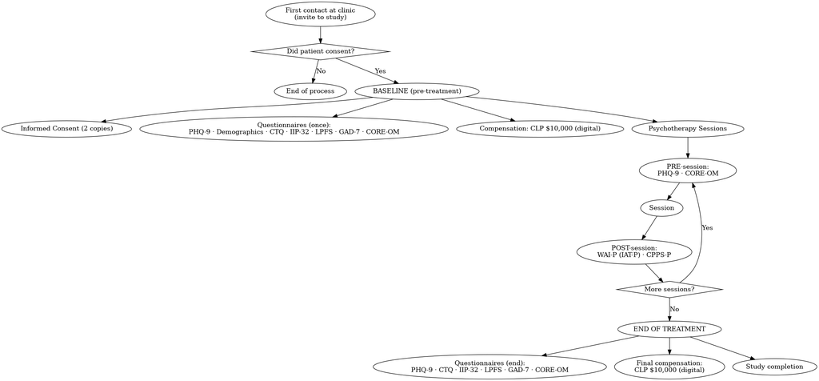

Click image to open full-size in a new tab

Patients are invited to participate at their first contact with the clinical institution. Participation requires **informed consent**. If consent is not provided, the process ends. If consent is granted, baseline assessments are collected before the first psychotherapy session, session-by-session measures are gathered throughout treatment, and end-of-treatment measures are administered at termination. Participants receive CLP $10,000 (digital gift card) after the initial assessments and CLP $10,000 again after completing end-of-treatment questionnaires.

##### **Phase 1 — First Contact / Baseline (before the 1st psychotherapy session)**

1. Informed consent (two copies; one for participant, one retained by research team; Ethics approved).
2. Baseline assessments (administered once unless noted):
- **PHQ-9** (Patient Health Questionnaire-9; depressive symptoms; severity bands: 1–4 minimal, 5–9 mild, 10–14 moderate, 15–19 moderately severe, 20–27 severe).
- **Demographic questionnaire** (gender, age, education, SES, ethnicity, therapy history, etc.).
- **CTQ** (Childhood Trauma Questionnaire; Emotional/Physical/Sexual Abuse, Emotional/Physical Neglect).
- **IIP-32** (Inventory of Interpersonal Problems; interpersonal difficulties / personality disorder screening).
- **LPFS** (Levels of Personality Functioning Scale).
- **GAD-7** (Generalized Anxiety Disorder-7).
- **CORE-OM** (34 items; 0–4 scale; higher = more problems; cut-off ≈ 10; subscales: well-being, problems/symptoms, functioning, risk).
- **MINI** (selected modules) administered once at intake by a trained psych professional (Major Depressive Episode, Dysthymia, (Hypo)Mania to rule out bipolar).
- Initial **compensation**: CLP $10,000 digital gift card upon completing consent + baseline interview/questionnaires.

##### **Phase 2 — Session-by-Session Tracking**

Before each session:

- **PHQ-9**
- **CORE-OM**

After each session:

- **WAI-P / IAT-P** (Working Alliance Inventory – patient version; 12 items; therapeutic alliance for the dyad).
- **CPPS-P** (Comparative Psychotherapy Process Scale – patient version; 20 items; adherence to CBT and interpersonal/psychoanalytic interventions in non-manualized treatments).

##### **Phase 3 — End of Treatment**

End-of-treatment assessments (administered at last session or shortly after):

- PHQ-9, CTQ, IIP-32, LPFS, GAD-7, CORE-OM.
- Final **compensation**: CLP $10,000 digital gift card after completing end-of-treatment questionnaires.

#### Therapists procedure

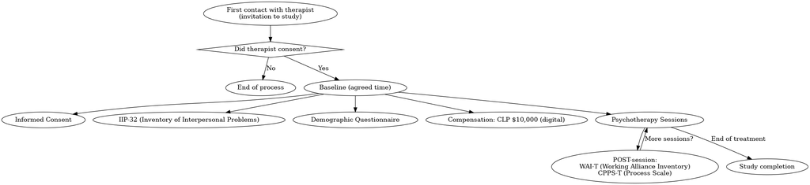

Click image to open full-size in a new tab

##### **Phase 1 — First Contact**

- Invitation: Therapist is approached to participate.
- Decision point: If the therapist does not consent → Process ends.
- If the therapist consents, the following instruments are administered (at a time agreed with the therapist):
1. **Informed Consent**
2. **IIP-32** (Inventory of Interpersonal Problems) — baseline only.
3. **Demographic Questionnaire** (gender, age, education, SES, therapy background, etc.) — baseline only.
4. **Compensation**: CLP $10,000 (digital gift card via email).

##### **Phase 2 — Session-by-Session Tracking**

After each psychotherapy session, therapists complete:

- **WAI-T** (Working Alliance Inventory – Therapist version; 12 items; assesses therapeutic alliance for each dyad).
- **CPPS-T** (Comparative Psychotherapy Process Scale – Therapist version; 20 items; adherence to CBT and interpersonal/psychoanalytic techniques in non-manualized treatment).

#### Important Information

In the initial phase of the project, several assessment instruments were administered that were subsequently revised. The following modifications were implemented:

1. The study initially focused on patients with major depressive disorder, which served as an inclusion criterion and was determined using the MINI diagnostic interview. This criterion was later removed; consequently, the MINI interview was no longer administered.
2. To assess depressive symptoms, the BDI self-report questionnaire was replaced with the PHQ-9 self-report questionnaire.
3. To assess personality, the IPO self-report questionnaire was replaced with the LPFS-BF-2.0 self-report questionnaire.

Therefore, the database may contain participants who have completed the MINI, BDI, and IPO questionnaires.

## About FIP 2024

**Click to expand**

### Theoretical Summary

Worldwide, the lifetime prevalence of Major Depressive Disorder is 10% to 15% of the population (Lépine & Briley, 2011), constituting the third cause of morbidity, and accounting for 4.3% of the global burden of illness (WHO, 2011). In Chile, the prevalence of symptoms of depression is 17% in the general population and 26% among women (MINSAL, 2010).

Treating depression is a priority due to the high subjective, social, and economic burden of the illness. However, treatment effectiveness is still somewhat disappointing (Craighead & Dunlop, 2014). The heterogeneity of depressive presentations may constitute a factor that dilutes treatment effectiveness (Fried, 2016). One of the forms of heterogeneity corresponds to a subtype of patients who have **early life maltreatment and adversity (ELMA)** (Nanni et al., 2012).

Childhood maltreatment is reported in 46% of patients with a diagnosis of depression (Nelson et al., 2016), and it is associated with attachment deficits (Egeland & Sroufe, 1981), impaired cognitive and affective functioning (Pechtel & Pizzagalli, 2011), and immune dysregulation (Fagundes et al., 2013). Individuals with ELMA present with higher rates of depression, have early onset, more severity, comorbidity, and suicide risk, and a smaller response rate (Teicher & Samson, 2013). Parental experience of maltreatment as a child is one of the most important predictors of child maltreatment (van IJzendoorn et al., 2020), and thus, working with parents’ own experiences of maltreatment helps stop the intergenerational transmission of violence (Lieberman et al., 2005).

In Chile, Vitriol et al. (2010) has shown the importance of focusing on ELMA in the treatment of women with severe depression with histories of ELMA. Also in our country, research has shown that patients are willing to report ELMA from the beginning of psychotherapy (Israel, 2019), especially if they receive an explanation that doing so is important for their diagnosis and treatment (Correa, 2017).

The proposed research is an observational case-match study that will evaluate the acceptability and effectiveness of providing **trauma-informed psychotherapy**, with automated feedback to patients and therapists regarding **ELMA**, in **depressed patients**.

### Ethics Committee Approval

This study was incorporated as an amendment to the ethical approval of the FONDECYT 1191299. This FONDECYT 1191299 was approved on May 2, 2019, by the Scientific Ethical Committee for Health Sciences of the Pontificia Universidad Católica de Chile (n° 180823024).

The amendment to include this study was approved on October 5, 2023.

### Specific Objectives of the Study

The **general objective** of this study is to evaluate the acceptability and effectiveness of providing trauma-informed psychotherapy, with automated feedback to patients and therapists regarding ELMA, in depressed patients.

The **specific objectives are**:

- Assess the **acceptability** for patients and therapists of the automated ELMA feedback.
- Assess the **effectiveness** of the trauma-focused psychotherapy providing patients and therapists with ELMA feedback.
- Assess if ELMA **moderates** which patients benefit most from this intervention.

### Specific Hypotheses of the Study

- The **ELMA automated feedback** will be considered **acceptable for patientsand therapists**.
- Patients in the condition that receives **trauma-informed psychotherapy** will have **greater rates of improvements** in their depressive symptomatology and overall psychological well being.
- Patients with **greater ELMA** will **benefit more from trauma-informed psychotherapy**.

### Study Design

#### Patients procedure

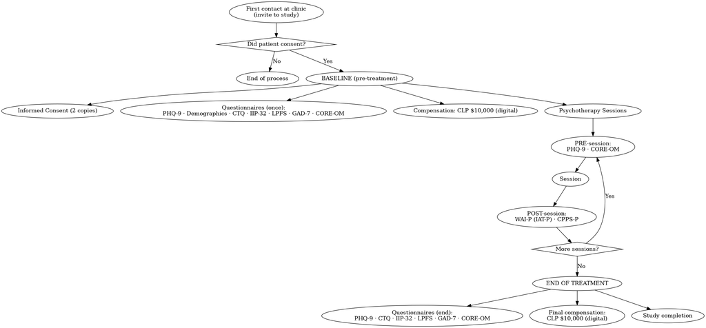

Click image to open full-size in a new tab

The procedure is the same as that described for the FONDECYT 1191299. The additional steps included in this study are:

1. Patients receive automated feedback on ELMA based on their CTQ-SF results. This feedback includes automated feedback on the presence of ELMA, psychoeducation on how ELMA may relate to depression and other presenting problems, and the importance of openly discussing ELMA during psychotherapy.
2. After receiving the feedback, patients complete a self-report questionnaire to assess the acceptability of the feedback and how these tools can be improved.

#### Therapists procedure

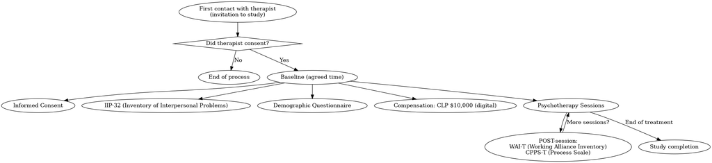

Click image to open full-size in a new tab

The procedure is the same as that described for the FONDECYT project. The additional steps included in this study are:

1. Therapists receive automated feedback on ELMA from their patients based on their CTQ-SF results.This feedback includes automated feedback on the presence of ELMA and training on working effectively with ELMA.
2. After receiving the feedback, patients complete a self-report questionnaire to assess the acceptability of the feedback and how these tools can be improved.

**Click to expand**

# Data Import and Overview

```
## 📂 Loading FONDECYT item responses data with complete metadata...
```

```
## ✅ numeric_value validation: All values are numeric
```

```
## ✅ character_value validation: All values are character/text
```

```
## ✅ administration_id validation: All values are numeric
```

```
## ✅ item_id validation: All values are numeric
```

```
## ✅ response_time_options validation: All values are character/text
```

```
## ✅ response_date validation: All values are valid datetime (POSIXct)
```

```
## ✅ session_therapist validation: All values are numeric
```

```
## ✅ response_updated validation: All values are valid datetime (POSIXct)
```

```
## ✅ subject_value_id validation: All values are numeric
```

```
## ✅ was_skipped validation: All values are boolean/logical
```

```
## ✅ item_label validation: All values are character/text
```

```
## ✅ item_text validation: All values are character/text
```

```
## ✅ item_measure_id validation: All values are numeric
```

```
## ✅ item_is_required validation: All values are boolean/logical
```

```
## ✅ item_position validation: All values are numeric
```

```
## ✅ admin_start_datetime validation: All values are valid datetime (POSIXct)
```

```
## ✅ admin_end_datetime validation: All values are valid datetime (POSIXct)
```

```
## ✅ admin_is_completed validation: All values are boolean/logical
```

```
## ✅ subject_type validation: All values are numeric (ready for factor conversion)
```

```
## ✅ subject_study_site_id validation: All values are numeric
```

```
## ✅ subject_id validation: All values are numeric
```

```
## ✅ session_id validation: All values are numeric
```

```
## ✅ session_number validation: All values are numeric
```

```
## ✅ session_attendance_status validation: All values are boolean/logical
```

```
## ✅ session_modality validation: All values are numeric (ready for factor conversion)
```

```
## ✅ session_comments validation: All values are character/text
```

### Data Loading Summary

**✅ Complete enhanced dataset loaded successfully!**

- **Dataset shape:** 686,741 rows × 31 columns
- **File size:** 1416 MB
- **Transformations applied:**
  - `subject_type` → factor (Patient/Therapist)
  - `session_modality` → factor (In Person/Remote/videocall/Other) ```

## Column Documentation

| Column | Type | Description | Sample_Values |
| --- | --- | --- | --- |
| item_id | numeric | Unique identifier for the specific question/item being answered | 119, 120, 172 |
| response_id | numeric | Unique identifier for each item response | 1543, 1544, 1470 |
| numeric_value | numeric | Numeric response value (for quantitative items) | 3, 0, 2 |
| character_value | character | Text/character response value (for qualitative items) | Espiritualidad a nivel general, creo en todas l..., 1985-11-05, 1986-04-12 |
| administration_id | numeric | Identifier linking to the measurement administration session. Subjects may have multiple administrations of a single measure. | 239, 206, 237 |
| response_time_options | character | The set of options the related item had when the response was recorded | 1, {"options": [{"label": "No", "value": 0}, {"lab..., {"options": [{"label": "Nunca", "value": 0}, {"... |
| response_date | POSIXct | Date and time when the response was originally created | 2020-11-22 21:46:17, 2021-07-13 20:19:30, 2021-06-30 18:18:53 |
| response_updated | POSIXct | Date and time when the response was last modified/updated (responses could be edited by subjects once created on the platform) | 2020-11-22 21:46:17, 2023-02-27 16:19:25, 2023-02-27 16:22:44 |
| subject_value_id | numeric | Identifier for subject-specific value (some items refer to another subject on the database) | 2056, 2094, 66 |
| was_skipped | logical | Boolean indicating if the item was skipped by the participant | FALSE, TRUE |

[output cut: 21 more lines]

## Data Summary Statistics

### Data Collection Period

**From:** 2020-11-22 21:46:17  
**To:** 2025-11-16 01:14:02  
**Span:** 1819.144 days

### Response Quality Metrics

**Skip Rate:** 0.01 % ( 60 out of 686,741 )

Table 4: Response Type Distribution

| Response Type | Count (%) |
| --- | --- |
| Numeric | 674,688 (98.2%) |
| Missing | 7,100 (1%) |
| Character | 4,953 (0.7%) |

## Dataset Preview

*Interactive preview of the first 100 rows with search and filtering capabilities.*

|  | response_id | numeric_value | character_value | administration_id | item_id | response_time_options | response_date | response_updated | subject_value_id | was_skipped | item_label | item_text | item_measure_id | item_is_required | item_position | item_notes | item_description_long | item_explanation | admin_start_datetime | admin_end_datetime | admin_is_completed | subject_type | subject_study_site_id | subject_study_site | subject_id | session_id | session_number | session_attendance_status | session_modality | … |
| --- | --- | --- | --- | --- | --- | --- | --- | --- | --- | --- | --- | --- | --- | --- | --- | --- | --- | --- | --- | --- | --- | --- | --- | --- | --- | --- | --- | --- | --- | --- |
| 1 | 1543 | 3 |  | 239 | 119 | 1 | 2020-11-22 21:46:17 | 2020-11-22 21:46:17 |  | False | GAD_7_1 | "Sentirse nervioso/a, ansioso/a, o con los nervios de punta" | 4 | True | 0 |  |  | 0=Para nada; 1= Varios días; 2=Más de la mitad de los días; 3=Casi todos los días. | 2020-11-17T11:18:54Z | 2020-11-20T13:42:17Z | True | Patient | 2 | Locación de prueba | 33 |  |  |  |  | … |
| 2 | 1544 | 3 |  | 239 | 120 | 1 | 2020-11-22 21:46:17 | 2020-11-22 21:46:17 |  | False | GAD_7_2 | "No poder dejar de preocuparse o no poder controlar la preocupación" | 4 | True | 1 |  |  | [REMOVE THIS ITEM] | 2020-11-17T11:18:54Z | 2020-11-20T13:42:17Z | True | Patient | 2 | Locación de prueba | 33 |  |  |  |  | … |
| 3 | 1470 | 0 |  | 206 | 172 | 1 | 2020-11-22 21:46:17 | 2020-11-22 21:46:17 |  | False | CORE_OM_29 | "Me he sentido irritable cuando estaba con otras personas" | 3 | False | 29 |  |  | 0=Nunca; 1=Muy pocas veces; 2=Algunas veces; 3=Muchas veces; 4=Siempre o casi siempre. | 2020-11-12T21:53:44Z | 2020-11-13T17:26:52Z | True | Patient | 2 | Locación de prueba | 31 |  |  |  |  | … |
| 4 | 1471 | 3 |  | 206 | 173 | 1 | 2020-11-22 21:46:17 | 2020-11-22 21:46:17 |  | False | CORE_OM_30 | "He pensado que yo tengo la culpa de mis problemas y dificultades" | 3 | False | 30 |  |  | 0=Nunca; 1=Muy pocas veces; 2=Algunas veces; 3=Muchas veces; 4=Siempre o casi siempre. | 2020-11-12T21:53:44Z | 2020-11-13T17:26:52Z | True | Patient | 2 | Locación de prueba | 31 |  |  |  |  | … |
| 5 | 1473 | 2 |  | 206 | 175 | 1 | 2020-11-22 21:46:17 | 2020-11-22 21:46:17 |  | False | CORE_OM_32 | "He conseguido las cosas que quería" | 3 | False | 32 |  |  | INVERSE: 0=Siempre o casi siempre; 1=Muchas veces; 2=Algunas veces; 3=Muy pocas veces; 4=Nunca. | 2020-11-12T21:53:44Z | 2020-11-13T17:26:52Z | True | Patient | 2 | Locación de prueba | 31 |  |  |  |  | … |
| 6 | 1534 | 3 |  | 237 | 705 | 1 | 2020-11-22 21:46:17 | 2023-02-27 16:19:25 |  | False | PHQ_9_1 | Durante las últimas 2 semanas ¿con qué frecuencia ha mostrado tener poco interés o placer en hacer las cosas? | 2 | False | 1 |  |  | 0=Nunca; 1=Varios días; 2=Más de la mitad de los días; 3=Casi todos los días. | 2020-11-17T11:18:54Z | 2020-11-20T13:41:50Z | True | Patient | 2 | Locación de prueba | 33 |  |  |  |  | … |
| 7 | 1474 | 0 |  | 206 | 176 | 1 | 2020-11-22 21:46:17 | 2020-11-22 21:46:17 |  | False | CORE_OM_33 | "Me he sentido humillado/a o avergonzado/a por otras personas" | 3 | False | 33 |  |  | 0=Nunca; 1=Muy pocas veces; 2=Algunas veces; 3=Muchas veces; 4=Siempre o casi siempre. | 2020-11-12T21:53:44Z | 2020-11-13T17:26:52Z | True | Patient | 2 | Locación de prueba | 31 |  |  |  |  | … |
| 8 | 1545 | 3 |  | 239 | 121 | 1 | 2020-11-22 21:46:17 | 2020-11-22 21:46:17 |  | False | GAD_7_3 | "No poder dejar de preocuparse o no poder controlar la preocupación" | 4 | True | 2 |  |  | 0=Para nada; 1= Varios días; 2=Más de la mitad de los días; 3=Casi todos los días. | 2020-11-17T11:18:54Z | 2020-11-20T13:42:17Z | True | Patient | 2 | Locación de prueba | 33 |  |  |  |  | … |
| 9 | 1546 | 3 |  | 239 | 122 | 1 | 2020-11-22 21:46:17 | 2020-11-22 21:46:17 |  | False | GAD_7_4 | "Preocuparse demasiado por diferentes cosas" | 4 | True | 3 |  |  | 0=Para nada; 1= Varios días; 2=Más de la mitad de los días; 3=Casi todos los días. | 2020-11-17T11:18:54Z | 2020-11-20T13:42:17Z | True | Patient | 2 | Locación de prueba | 33 |  |  |  |  | … |
| 10 | 1536 | 3 |  | 237 | 707 | 1 | 2020-11-22 21:46:17 | 2023-02-27 16:22:44 |  | False | PHQ_9_3 | Durante las últimas 2 semanas ¿con qué frecuencia ha tenido problemas en dormirse o en mantenerse dormido/a, o en dormir demasiado? | 2 | False | 3 |  |  | 0=Nunca; 1=Varios días; 2=Más de la mitad de los días; 3=Casi todos los días. | 2020-11-17T11:18:54Z | 2020-11-20T13:41:50Z | True | Patient | 2 | Locación de prueba | 33 |  |  |  |  | … |

[output cut: 90 more lines]

## Data Dimensions and Structure

### Dataset Structure

**Data consistency check:** Each row represents a unique response: ** ✅ PASSED **

Table 5: Dataset Dimensions

[output not shown]

## Dataset Composition Analysis

### Research Participants Overview

**Total unique subjects:** 942

**Patient-to-Therapist Ratio:** 6.2 :1

Table 3: Dataset Composition by Subject Type

| Subject Type | Unique Subjects | Total Responses | Avg Responses per Subject |
| --- | --- | --- | --- |
| Patient | 811 (86.1%) | 567,897 (82.7%) | 700.2 |
| Therapist | 131 (13.9%) | 118,844 (17.3%) | 907.2 |

### All Measures (Including Inactive)

*Complete inventory of all measures in the database for reference.*

|  | ID | Title | Label | Description |
| --- | --- | --- | --- | --- |
| 1 | 1 | MINI: Entrevista Neuropsiquiátrica Internacional |  | Evaluador: Comience la entrevista con el participante usando la siguiente consigna:"Hola, En primer lugar, le agradezco su tiempo y disposición en participar del estudio. Ahora le voy a realizar una s… |
| 2 | 2 | PHQ-9 | PHQ_9 | La escala de autorreporte de depresi&oacute;n PHQ-9 PHQ-9 (Patient Health Questionnaire) consta de 9 &iacute;tems que eval&uacute;an la presencia de s&iacute;ntomas depresivos (de acuerdo a criterios … |
| 3 | 3 | Cuestionario CORE-OM | CORE_OM | IMPORTANTE: POR FAVOR LEA ESTO ANTES DE EMPEZAR EL TEST.A continuaci&oacute;n encontrar&aacute; 34 frases. Lea cada frase y piense con qu&eacute; frecuencia usted se ha sentido as&iacute;&nbsp;durante… |
| 4 | 4 | Cuestionario GAD-7 | GAD_7 | Durante las &uacute;ltimas 2 semanas, &iquest;con qu&eacute; frecuencia ha sentido molestias por los siguientes problemas?&nbsp; |
| 5 | 5 | SCOFF |  |  |
| 6 | 6 | Cuestionario LPFS-BF | LPFS_BF | Instrucciones: Indique para cada una de las siguientes afirmaciones hasta qu&eacute; punto aplican para ti en este momento |
| 7 | 7 | BDI-IA |  |  |
| 8 | 8 | USM - Christus Ingreso Social |  |  |
| 9 | 9 | MDQ |  |  |
| 10 | 10 | AUDIT |  |  |

[output cut: 25 more lines]

### Notes for Researchers

- **Excluded Measures:** The following measures were excluded from the current analysis: 34, 29, 28, 27, 26, 24, 23, 22, 21, 8
- **Data Source:** Measure metadata extracted from `dump-fondecyt-202507271125.sql`
- **Last Updated:** 2026-04-07
- **File Location:** Measure metadata saved to `data/measure_metadata.csv`

## Wide Patient-Item Matrix (Patients as Rows)

This section constructs a wide-format representation where each row is a patient and each column is a specific item response from a specific administration of a measure. Column naming follows the pattern:

- Naming: `MEASURECODE_ITEMPOSITION_tN`
- Example: `PHQ_9_1_t1`, `PHQ_9_2_t1`, …, `PHQ_9_1_t2` for a patient with two PHQ-9 administrations.

Rules: - Subject: Only patients are included (subject_type = “Patient”). - Ordering: Administrations are ordered by `admin_start_datetime` per subject × measure; items ordered by `item_position` within each administration. - Values: Numeric responses when available; otherwise character responses. All values stored as text in the wide CSV.

```
##
## ✅ Wide matrix saved to: data/patient_item_matrix_wide_202507271125.csv
```

```
## 📘 Dictionary saved to: data/patient_item_matrix_wide_dictionary_202507271125.csv
```

### Wide Matrix Summary

- Rows (patients): 811
- Columns (responses): 5099
- Example columns: CORE_OM_0_t1, CORE_OM_1_t1, CORE_OM_2_t1, CORE_OM_3_t1, CORE_OM_4_t1, CORE_OM_5_t1, CORE_OM_6_t1, CORE_OM_7_t1

### Wide Matrix Preview

| subject_id | CORE_OM_0_t1 | CORE_OM_1_t1 | CORE_OM_2_t1 | CORE_OM_3_t1 | CORE_OM_4_t1 | CORE_OM_5_t1 | CORE_OM_6_t1 | CORE_OM_7_t1 | CORE_OM_8_t1 | CORE_OM_9_t1 | CORE_OM_10_t1 | CORE_OM_11_t1 | CORE_OM_12_t1 | CORE_OM_13_t1 | CORE_OM_14_t1 | CORE_OM_15_t1 | CORE_OM_16_t1 | CORE_OM_17_t1 | CORE_OM_18_t1 | CORE_OM_19_t1 | CORE_OM_20_t1 | CORE_OM_21_t1 | CORE_OM_22_t1 | CORE_OM_23_t1 | CORE_OM_24_t1 |
| --- | --- | --- | --- | --- | --- | --- | --- | --- | --- | --- | --- | --- | --- | --- | --- | --- | --- | --- | --- | --- | --- | --- | --- | --- | --- |
| 31 |  | 1 | 2 | 3 | 2 | 2 | 0 | 2 | 0 | 0 | 1 | 3 | 2 | 2 | 0 | 1 | 0 | 2 | 2 | 4 | 2 | 2 | 0 | 1 | 0 |
| 33 |  |  |  |  |  |  |  |  |  |  |  |  |  |  |  |  |  |  |  |  |  |  |  |  |  |
| 36 |  | 1 | 3 | 4 | 4 | 2 | 0 | 3 | 3 | 0 | 2 | 2 | 3 | 2 | 2 | 3 | 0 | 2 | 3 | 3 | 2 | 3 | 0 | 1 | 0 |
| 37 |  | 2 | 3 | 3 | 2 | 1 | 0 | 1 | 2 | 0 | 3 | 3 | 4 | 4 | 1 | 1 | 1 | 2 | 0 | 4 | 3 | 4 | 0 | 3 | 2 |
| 38 |  | 2 | 3 | 3 | 3 | 3 | 1 | 3 | 2 | 2 | 2 | 2 | 2 | 2 | 2 | 2 | 1 | 2 | 3 | 1 | 2 | 2 | 0 | 2 | 2 |
| 39 |  | 4 | 4 | 3 | 3 | 4 | 0 | 2 | 3 | 3 | 4 | 4 | 4 | 4 | 3 | 4 | 3 | 4 | 3 | 2 | 4 | 3 | 0 | 4 | 4 |
| 43 |  |  |  |  |  |  |  |  |  |  |  |  |  |  |  |  |  |  |  |  |  |  |  |  |  |
| 44 |  |  |  |  |  |  |  |  |  |  |  |  |  |  |  |  |  |  |  |  |  |  |  |  |  |
| 46 |  |  |  |  |  |  |  |  |  |  |  |  |  |  |  |  |  |  |  |  |  |  |  |  |  |
| 49 |  |  |  |  |  |  |  |  |  |  |  |  |  |  |  |  |  |  |  |  |  |  |  |  |  |

[output cut: 801 more lines]

### Variable Dictionary (Preview)

| column_name | measure_id | measure_code | measure_title | measure_label | item_position | admin_seq |
| --- | --- | --- | --- | --- | --- | --- |
| MEASURE_9_0_t1 | 9 |  | MDQ | NA | 0 | 1 |
| MEASURE_5_0_t1 | 5 |  | SCOFF | NA | 0 | 1 |
| MEASURE_10_0_t1 | 10 |  | AUDIT | NA | 0 | 1 |
| MEASURE_11_0_t1 | 11 |  | PCL-5 | NA | 0 | 1 |
| MEASURE_7_0_t1 | 7 |  | BDI-IA | NA | 0 | 1 |
| MEASURE_9_1_t1 | 9 |  | MDQ | NA | 1 | 1 |
| MEASURE_5_1_t1 | 5 |  | SCOFF | NA | 1 | 1 |
| MEASURE_10_1_t1 | 10 |  | AUDIT | NA | 1 | 1 |
| MEASURE_11_1_t1 | 11 |  | PCL-5 | NA | 1 | 1 |
| MEASURE_7_1_t1 | 7 |  | BDI-IA | NA | 1 | 1 |
| MEASURE_9_2_t1 | 9 |  | MDQ | NA | 2 | 1 |
| MEASURE_5_2_t1 | 5 |  | SCOFF | NA | 2 | 1 |
| MEASURE_10_2_t1 | 10 |  | AUDIT | NA | 2 | 1 |
| MEASURE_11_2_t1 | 11 |  | PCL-5 | NA | 2 | 1 |
| MEASURE_7_2_t1 | 7 |  | BDI-IA | NA | 2 | 1 |
| MEASURE_9_3_t1 | 9 |  | MDQ | NA | 3 | 1 |
| MEASURE_5_3_t1 | 5 |  | SCOFF | NA | 3 | 1 |
| MEASURE_10_3_t1 | 10 |  | AUDIT | NA | 3 | 1 |
| MEASURE_11_3_t1 | 11 |  | PCL-5 | NA | 3 | 1 |
| MEASURE_7_3_t1 | 7 |  | BDI-IA | NA | 3 | 1 |
| MEASURE_9_4_t1 | 9 |  | MDQ | NA | 4 | 1 |
| MEASURE_5_4_t1 | 5 |  | SCOFF | NA | 4 | 1 |
| MEASURE_10_4_t1 | 10 |  | AUDIT | NA | 4 | 1 |
| MEASURE_11_4_t1 | 11 |  | PCL-5 | NA | 4 | 1 |
| MEASURE_7_4_t1 | 7 |  | BDI-IA | NA | 4 | 1 |
| MEASURE_9_5_t1 | 9 |  | MDQ | NA | 5 | 1 |
| MEASURE_10_5_t1 | 10 |  | AUDIT | NA | 5 | 1 |
| MEASURE_11_5_t1 | 11 |  | PCL-5 | NA | 5 | 1 |
| MEASURE_7_5_t1 | 7 |  | BDI-IA | NA | 5 | 1 |
| MEASURE_9_6_t1 | 9 |  | MDQ | NA | 6 | 1 |
| MEASURE_10_6_t1 | 10 |  | AUDIT | NA | 6 | 1 |
| MEASURE_11_6_t1 | 11 |  | PCL-5 | NA | 6 | 1 |
| MEASURE_7_6_t1 | 7 |  | BDI-IA | NA | 6 | 1 |
| MEASURE_9_7_t1 | 9 |  | MDQ | NA | 7 | 1 |
| MEASURE_10_7_t1 | 10 |  | AUDIT | NA | 7 | 1 |
| MEASURE_11_7_t1 | 11 |  | PCL-5 | NA | 7 | 1 |
| MEASURE_7_7_t1 | 7 |  | BDI-IA | NA | 7 | 1 |
| MEASURE_9_8_t1 | 9 |  | MDQ | NA | 8 | 1 |
| MEASURE_10_8_t1 | 10 |  | AUDIT | NA | 8 | 1 |
| MEASURE_11_8_t1 | 11 |  | PCL-5 | NA | 8 | 1 |
| MEASURE_7_8_t1 | 7 |  | BDI-IA | NA | 8 | 1 |
| MEASURE_9_9_t1 | 9 |  | MDQ | NA | 9 | 1 |
| MEASURE_11_9_t1 | 11 |  | PCL-5 | NA | 9 | 1 |
| MEASURE_7_9_t1 | 7 |  | BDI-IA | NA | 9 | 1 |
| MEASURE_9_10_t1 | 9 |  | MDQ | NA | 10 | 1 |
| MEASURE_11_10_t1 | 11 |  | PCL-5 | NA | 10 | 1 |
| MEASURE_7_10_t1 | 7 |  | BDI-IA | NA | 10 | 1 |
| MEASURE_9_11_t1 | 9 |  | MDQ | NA | 11 | 1 |
| MEASURE_11_11_t1 | 11 |  | PCL-5 | NA | 11 | 1 |
| MEASURE_7_11_t1 | 7 |  | BDI-IA | NA | 11 | 1 |